# ggbio: Biological data plots

SISBID 2016

Di Cook (dicook@monash.edu, @visnut); Heike Hofmann (heike.hofmann@gmail.com, @heike_hh); edited by Alexej Gossmann

2016-07-15

## What is ggbio?

This is a package originally developed by Tengfei Yin and Michael Lawrence building on ggplot2, making it easier to produce some standard genomic plots.

- manhattan plot
- ideogram
- tracks
- circular layout

## Manhattan plot

- A Manhattan plot is special scatter plot used to visualize data with a large number of data points, often with some high-magnitude values, along a genomic reference like chromosome number
- `plotGrandLinear` function

```r
snp <- read.table(system.file("extdata", "plink.assoc.sub.txt",
    package = "biovizBase"), header = TRUE)
gr.snp <- transformDfToGr(snp, seqnames = "CHR", start = "BP",
    width = 1)
head(gr.snp)
```

```
#> GRanges object with 6 ranges and 10 metadata columns:
#>       seqnames                 ranges strand |       CHR        SNP
#>          <Rle>              <IRanges>  <Rle> | <integer>   <factor>
#>   [1]        4 [ 10794096,  10794099]      * |         4  rs9291494
#>   [2]       14 [ 55853742,  55853755]      * |        14  rs1152481
#>   [3]        6 [ 55188853,  55188858]      * |         6  rs3134708
#>   [4]       17 [  4146033,   4146049]      * |        17  rs2325988
#>   [5]       19 [ 46089501,  46089519]      * |        19  rs8103444
#>   [6]        1 [107051695, 107051695]      * |         1 rs12072065
#>              BP       A1       F_A       F_U       A2     CHISQ         P
#>       <integer> <factor> <numeric> <numeric> <factor> <numeric> <numeric>
#>   [1]  10794096        G    0.3061    0.1341        A    7.5070  0.006147
#>   [2]  55853742        G    0.3542    0.2805        A    1.1030  0.293600
#>   [3]  55188853        C    0.2500    0.2875        A    0.3135  0.575500
#>   [4]   4146033        G    0.2551    0.2317        A    0.1323  0.716100
#>   [5]  46089501        C    0.3980    0.2927        A    2.1750  0.140300
#>   [6] 107051695        0    0.0000    0.0000        C      <NA>      <NA>
#>              OR
#>       <numeric>
#>   [1]    2.8480
#>   [2]    1.4070
#>   [3]    0.8261
#>   [4]    1.1360
#>   [5]    1.5970
#>   [6]      <NA>
#>   -------
#>   seqinfo: 22 sequences from an unspecified genome; no seqlengths
```

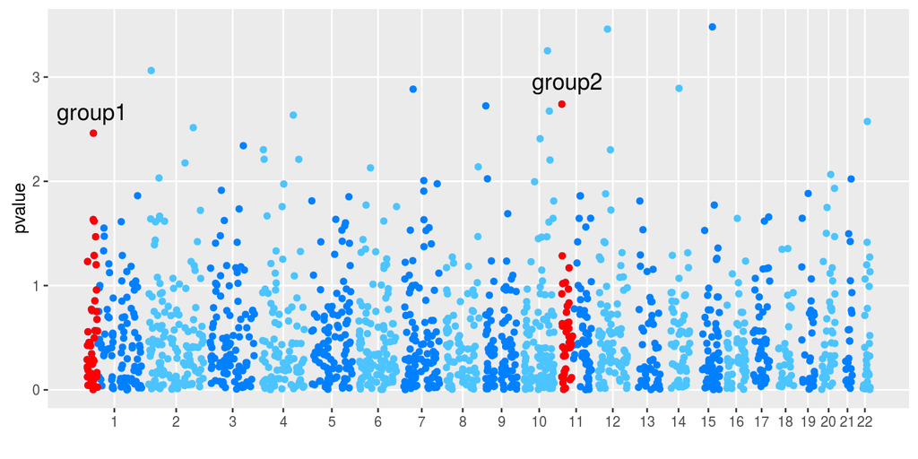

```r
gr.snp <- keepSeqlevels(gr.snp, as.character(1:22))
data(ideoCyto, package = "biovizBase")
seqlengths(gr.snp) <- as.numeric(seqlengths(ideoCyto$hg18)[1:22])
gr.snp <- gr.snp[!is.na(gr.snp$P)]
values(gr.snp)$pvalue <- -log10(values(gr.snp)$P)
gro <- GRanges(c("1", "11"), IRanges(c(100, 2e6), width = 5e7))
names(gro) <- c("group1", "group2")
plotGrandLinear(gr.snp, aes(y = pvalue), highlight.gr = gro)
```

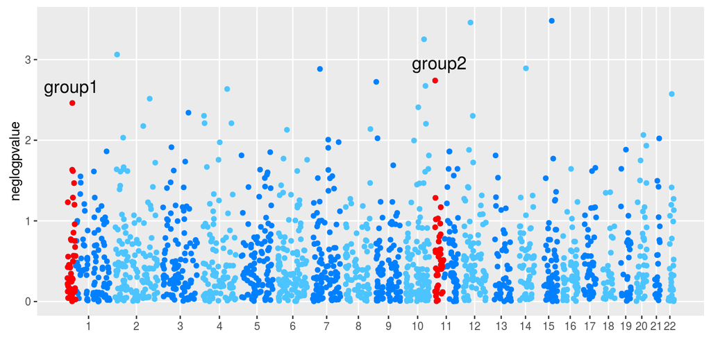

```r
gr.snp <- keepSeqlevels(gr.snp, as.character(1:22))
data(ideoCyto, package = "biovizBase")
seqlengths(gr.snp) <- as.numeric(seqlengths(ideoCyto$hg18)[1:22])
gr.snp <- gr.snp[!is.na(gr.snp$P)]
values(gr.snp)$neglogpvalue <- -log10(values(gr.snp)$P)
gro <- GRanges(c("1", "11"), IRanges(c(100, 2e6), width = 5e7))
names(gro) <- c("group1", "group2")
plotGrandLinear(gr.snp, aes(y = neglogpvalue), highlight.gr = gro)
```

## Ideogram

This is a plot of a single chromosome with cytoband.

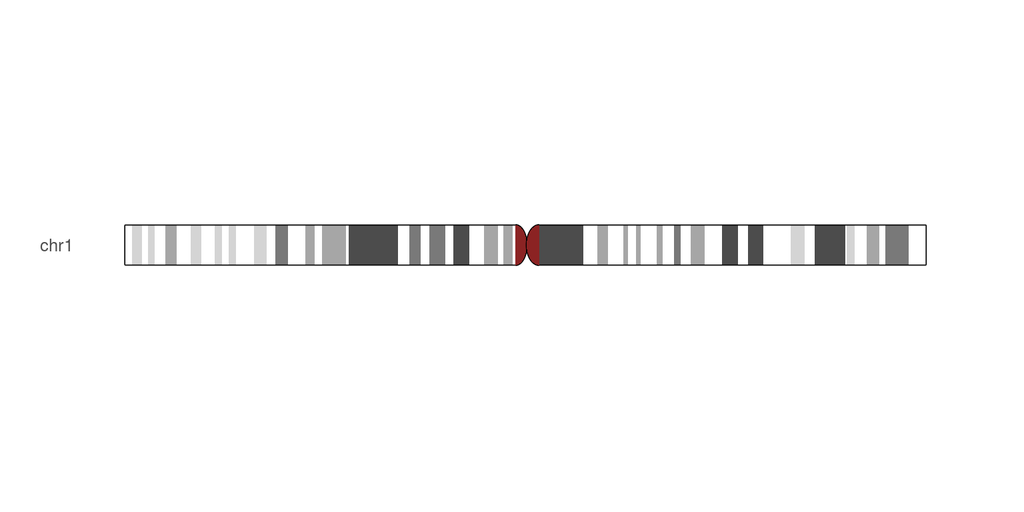

```r
p.ideo <- Ideogram(genome = "hg19")
p.ideo
```

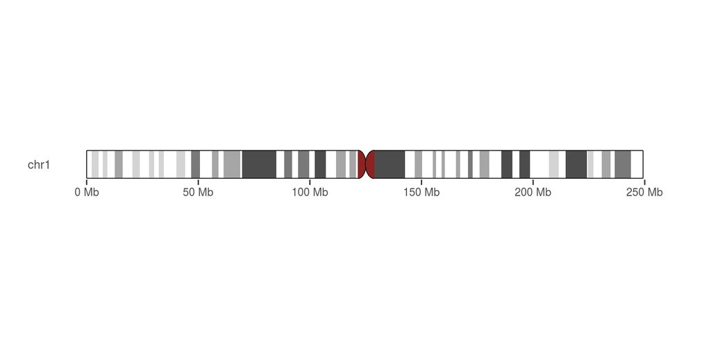

```r
Ideogram(genome = "hg19", xlabel = TRUE)
```

## Tracks

Lining up multiple plots along the chromosome is an important part of plotting genomic data

```r
library(Homo.sapiens)
class(Homo.sapiens)
```

```
#> [1] "OrganismDb"
#> attr(,"package")
#> [1] "OrganismDbi"
```

```r
data(genesymbol, package = "biovizBase")
wh <- genesymbol[c("BRCA1", "NBR1")]
wh <- range(wh, ignore.strand = TRUE)
```

## Gene model

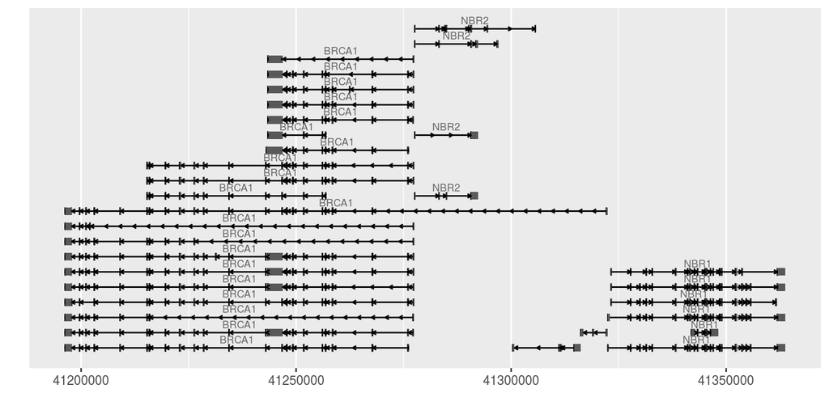

```r
p.txdb <- autoplot(Homo.sapiens, which = wh)
p.txdb
```

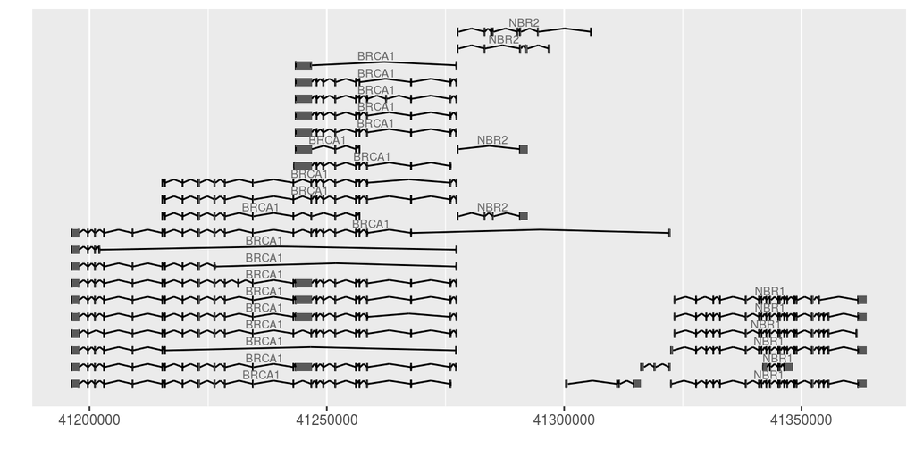

```r
autoplot(Homo.sapiens, which = wh, gap.geom = "chevron")
```

## Base locations

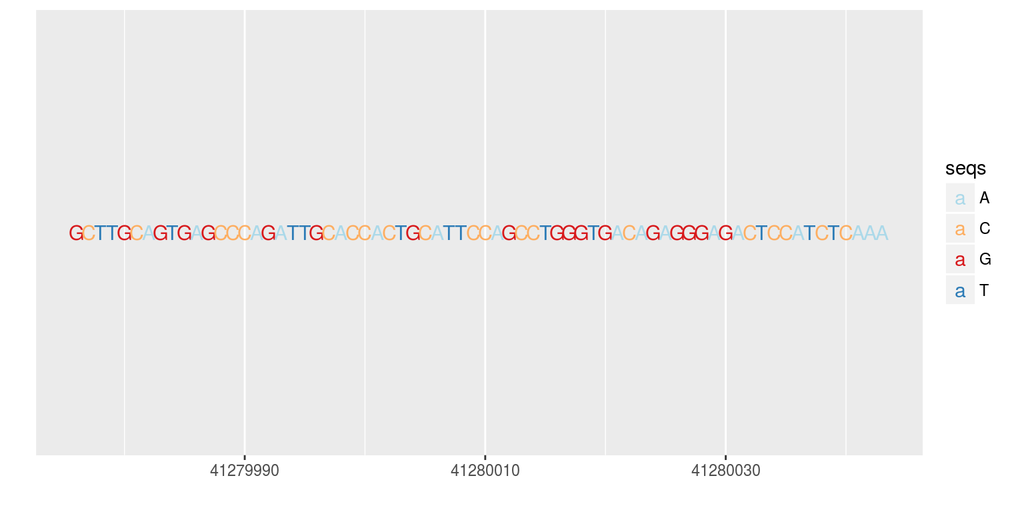

```r
library(BSgenome.Hsapiens.UCSC.hg19)
bg <- BSgenome.Hsapiens.UCSC.hg19
p.bg <- autoplot(bg, which = wh)
## no geom
#p.bg
## segment
#p.bg + zoom(1/100)
## rectangle
#p.bg + zoom(1/1000)
## text
p.bg + zoom(1/2500)
```

## Your turn

What is plotted at `zoom(1/100)` resolution?

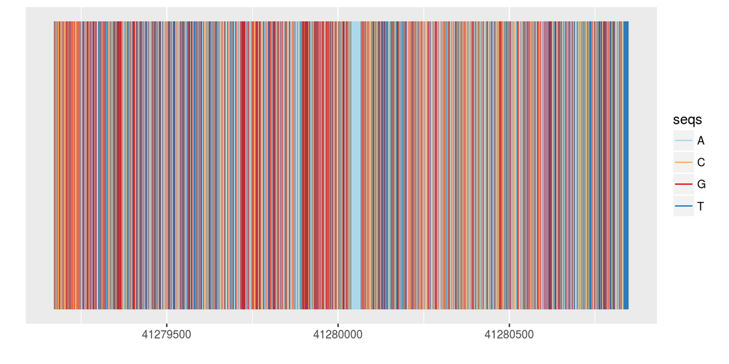

```r
bg <- BSgenome.Hsapiens.UCSC.hg19
p.bg <- autoplot(bg, which = wh)
p.bg + zoom(1/100)
```

## Base locations

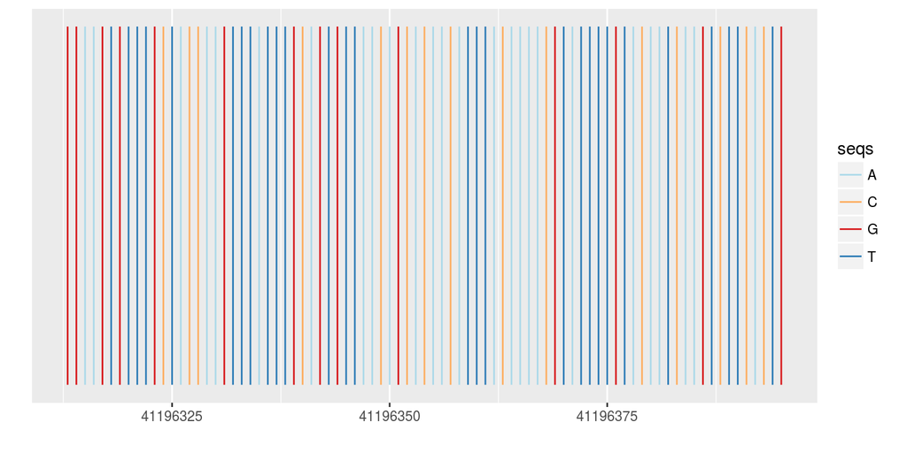

```r
bg <- BSgenome.Hsapiens.UCSC.hg19
## force to use geom segment at this level
autoplot(bg, which = resize(wh, width = width(wh)/2000), geom = "segment")
```

## Plot coverage

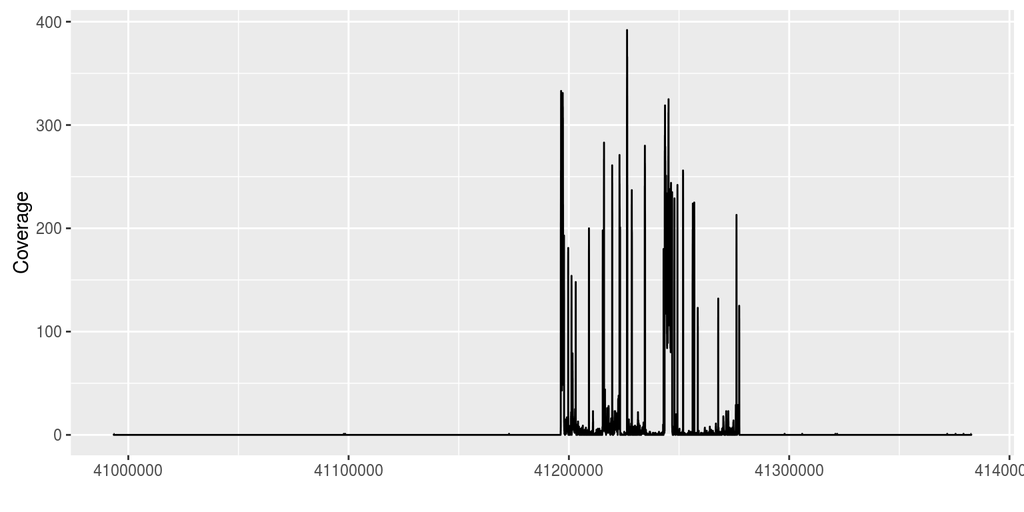

```r
fl.bam <- system.file("extdata", "wg-brca1.sorted.bam", package = "biovizBase")
wh <- keepSeqlevels(wh, "chr17")
autoplot(fl.bam, which = wh)
```

## Plot mismatches

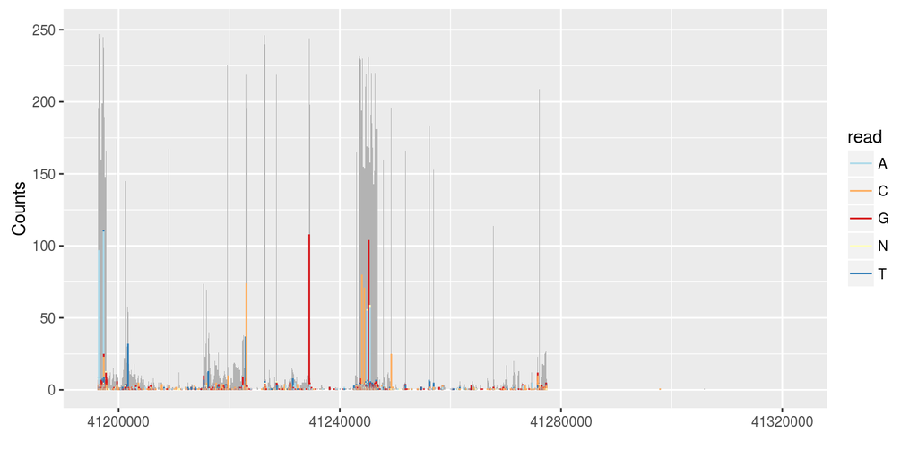

```r
bg <- BSgenome.Hsapiens.UCSC.hg19
p.mis <- autoplot(fl.bam, bsgenome = bg, which = wh, stat = "mismatch")
p.mis
```

## Putting it together with tracks

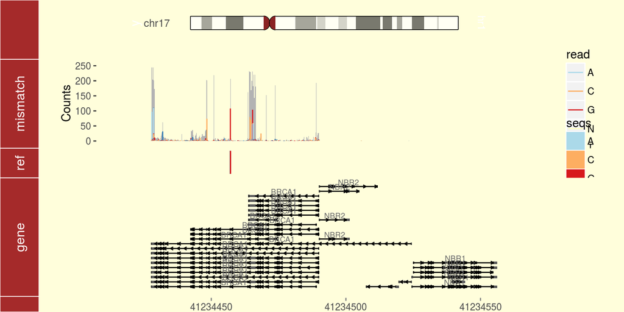

```r
p.ideo <- Ideogram(genome = "hg19")
gr17 <- GRanges("chr17", IRanges(41234415, 41234569))
tks <- tracks(p.ideo, mismatch = p.mis, ref = p.bg, gene = p.txdb,
  heights = c(2, 3, 1, 4)) + xlim(gr17) + theme_tracks_sunset()
tks
```

## Circular layout

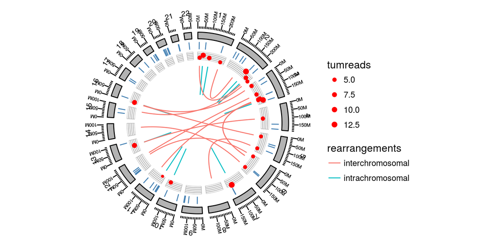

```r
data("CRC", package = "biovizBase")
gr.crc1 <- crc.gr[values(crc.gr)$individual == "CRC-1"]
p <- ggbio() +
    circle(gr.crc1, geom = "link", linked.to = "to.gr",
      aes(color = rearrangements)) +
    circle(gr.crc1, geom = "point", aes(y = score, size = tumreads),
      color = "red", grid = TRUE) + scale_size(range = c(1, 2.5)) +
    circle(mut.gr, geom = "rect", color = "steelblue") +
    circle(hg19sub, geom = "ideo", fill = "gray70") +
    circle(hg19sub, geom = "scale", size = 2) +
    circle(hg19sub, geom = "text", aes(label = seqnames),
      vjust = 0, size = 3)
p
```

## Your turn

Which `circle` line of code plots the circle segments (grey filled) representing the chromosomes?

```r
circle(hg19sub, geom = "ideo", fill = "gray70") +
```

## Resources

- Yin T, Cook D and Lawrence M (2012). “ggbio: an R package for extending the grammar of graphics for genomic data.” Genome Biology, 13(8), pp. R77.
- [bioconductor page](https://bioconductor.org/packages/release/bioc/html/ggbio.html)

## Share and share alike

This work is licensed under the Creative Commons Attribution-Noncommercial 3.0 United States License. To view a copy of this license, visit http://creativecommons.org/licenses/by-nc/ 3.0/us/ or send a letter to Creative Commons, 171 Second Street, Suite 300, San Francisco, California, 94105, USA.